# ClustIRR Benchmarking

# TL;DR

- Motifs successfully detected accross all versions
- Global similarites also found (same algorithm for all versions)
- OvE values for all versions roughly comparable to ground truth
  - Small deviations caused by difference in ground truth calculation formula against FET in v2/3
  - Noisy motifs in v1 supposedly caused by bootstrapping vs gt calculation
- p-value of v1 seems to be lacking precision compared to v2/3
  - leads to fdr of version 1 being lower than v2/3
  - leads to v1 detecting more motifs than v2/3 (effectively lowered detection threshold)
  - after some testing seems to be related to formula of version 1

## Input parameters

```r
# v1 + v2 + v3
ks <- 4
cores <- parallel::detectCores()

control_input <- list(
  B = 1000,
  global_max_dist = 1,
  local_max_fdr = 0.05,
  local_min_ove = 2,
  local_min_o = 3,
  trim_flank_aa = 0,
  low_mem = FALSE,
  global_pairs = NULL)
```

## Check implanted motifs

Implanted motif **RQWW** gets found in all versions.  
When using clonal expanded data_sample as input, only version 3 finds more motifs.  
Version 1 and 2 find less motifs when expanded because of motifs near threshold, see below in section about **p-value**/**fdr**.  
Reason for version 1 finding more motifs when not expanded could be **p-value** being calculated differently

found motifs

| version | no_exp | exp |
| --- | --- | --- |
| 1 | 13 | 12 |
| 2 | 4 | 3 |
| 3 | 4 | 25 |

v1

|  | mean_f_ref | min_f_ref | max_f_ref | f_sample | ove | p_value | motif | fdr | k | pass |
| --- | --- | --- | --- | --- | --- | --- | --- | --- | --- | --- |
| RQWW | 0.000 | 0 | 0 | 20 | Inf | 0.000 | RQWW | 0.0000000 | 4 | TRUE |
| WTEA | 0.769 | 0 | 5 | 6 | 7.802341 | 0.000 | WTEA | 0.0000000 | 4 | TRUE |
| SLRQ | 0.462 | 0 | 3 | 6 | 12.987013 | 0.000 | SLRQ | 0.0000000 | 4 | TRUE |
| LRQW | 0.000 | 0 | 0 | 6 | Inf | 0.000 | LRQW | 0.0000000 | 4 | TRUE |
| QWWG | 0.000 | 0 | 0 | 4 | Inf | 0.000 | QWWG | 0.0000000 | 4 | TRUE |
| WWDT | 0.000 | 0 | 0 | 3 | Inf | 0.000 | WWDT | 0.0000000 | 4 | TRUE |
| SSGK | 0.284 | 0 | 3 | 3 | 10.563380 | 0.001 | SSGK | 0.0489683 | 4 | TRUE |
| SQTS | 0.326 | 0 | 3 | 3 | 9.202454 | 0.001 | SQTS | 0.0489683 | 4 | TRUE |
| RVGL | 0.151 | 0 | 2 | 3 | 19.867550 | 0.000 | RVGL | 0.0000000 | 4 | TRUE |
| RAQE | 0.238 | 0 | 3 | 3 | 12.605042 | 0.001 | RAQE | 0.0489683 | 4 | TRUE |
| QWWD | 0.000 | 0 | 0 | 3 | Inf | 0.000 | QWWD | 0.0000000 | 4 | TRUE |
| GNSN | 0.221 | 0 | 2 | 3 | 13.574661 | 0.000 | GNSN | 0.0000000 | 4 | TRUE |
| GDIQ | 0.239 | 0 | 2 | 3 | 12.552301 | 0.000 | GDIQ | 0.0000000 | 4 | TRUE |

v2

|  | motif | f_sample | n_sample | f_ref | n_ref | k | ove | ove_ci_l95 | ove_ci_h95 | p_value | fdr | pass |
| --- | --- | --- | --- | --- | --- | --- | --- | --- | --- | --- | --- | --- |
| 1970 | RQWW | 20 | 5864 | 0 | 116615 | 4 | Inf | 123.213122 | Inf | 0.00e+00 | 0.0000000 | TRUE |
| 1411 | LRQW | 6 | 5864 | 0 | 116615 | 4 | Inf | 30.738253 | Inf | 0.00e+00 | 0.0000185 | TRUE |
| 2254 | SLRQ | 6 | 5864 | 10 | 116615 | 4 | 11.94065 | 4.301924 | Inf | 6.34e-05 | 0.0489108 | TRUE |
| 1799 | QWWG | 4 | 5864 | 0 | 116615 | 4 | Inf | 17.848031 | Inf | 5.20e-06 | 0.0053981 | TRUE |

v3

|  | motif | f_sample | n_sample | f_ref | n_ref | k | ove | ove_ci_l95 | ove_ci_h95 | p_value | fdr | pass |
| --- | --- | --- | --- | --- | --- | --- | --- | --- | --- | --- | --- | --- |
| 1970 | RQWW | 20 | 5864 | 0 | 116615 | 4 | Inf | 123.213122 | Inf | 0.00e+00 | 0.0000000 | TRUE |
| 1411 | LRQW | 6 | 5864 | 0 | 116615 | 4 | Inf | 30.738253 | Inf | 0.00e+00 | 0.0000185 | TRUE |
| 2254 | SLRQ | 6 | 5864 | 10 | 116615 | 4 | 11.94065 | 4.301924 | Inf | 6.34e-05 | 0.0489108 | TRUE |
| 1799 | QWWG | 4 | 5864 | 0 | 116615 | 4 | Inf | 17.848031 | Inf | 5.20e-06 | 0.0053981 | TRUE |

v1 exp

|  | mean_f_ref | min_f_ref | max_f_ref | f_sample | ove | p_value | motif | fdr | k | pass |
| --- | --- | --- | --- | --- | --- | --- | --- | --- | --- | --- |
| RQWW | 0.000 | 0 | 0 | 20 | Inf | 0.000 | RQWW | 0.0000000 | 4 | TRUE |
| WTEA | 0.761 | 0 | 4 | 6 | 7.884363 | 0.000 | WTEA | 0.0000000 | 4 | TRUE |
| SLRQ | 0.539 | 0 | 4 | 6 | 11.131725 | 0.000 | SLRQ | 0.0000000 | 4 | TRUE |
| LRQW | 0.000 | 0 | 0 | 6 | Inf | 0.000 | LRQW | 0.0000000 | 4 | TRUE |
| QWWG | 0.000 | 0 | 0 | 4 | Inf | 0.000 | QWWG | 0.0000000 | 4 | TRUE |
| WWDT | 0.000 | 0 | 0 | 3 | Inf | 0.000 | WWDT | 0.0000000 | 4 | TRUE |
| WDTQ | 0.261 | 0 | 3 | 3 | 11.494253 | 0.001 | WDTQ | 0.0455735 | 4 | TRUE |
| SQTS | 0.294 | 0 | 3 | 3 | 10.204082 | 0.001 | SQTS | 0.0455735 | 4 | TRUE |
| RVGL | 0.133 | 0 | 2 | 3 | 22.556391 | 0.000 | RVGL | 0.0000000 | 4 | TRUE |
| RAQE | 0.291 | 0 | 3 | 3 | 10.309278 | 0.001 | RAQE | 0.0455735 | 4 | TRUE |
| QWWD | 0.000 | 0 | 0 | 3 | Inf | 0.000 | QWWD | 0.0000000 | 4 | TRUE |
| GDIQ | 0.250 | 0 | 3 | 3 | 12.000000 | 0.001 | GDIQ | 0.0455735 | 4 | TRUE |

v2 exp

|  | motif | f_sample | n_sample | f_ref | n_ref | k | ove | ove_ci_l95 | ove_ci_h95 | p_value | fdr | pass |
| --- | --- | --- | --- | --- | --- | --- | --- | --- | --- | --- | --- | --- |
| 1982 | RQWW | 20 | 5898 | 0 | 116615 | 4 | Inf | 122.46077 | Inf | 0.0e+00 | 0.0000000 | TRUE |
| 1420 | LRQW | 6 | 5898 | 0 | 116615 | 4 | Inf | 30.56676 | Inf | 0.0e+00 | 0.0000192 | TRUE |
| 1810 | QWWG | 4 | 5898 | 0 | 116615 | 4 | Inf | 17.74445 | Inf | 5.4e-06 | 0.0055433 | TRUE |

v3 exp

|  | motif | f_sample | n_sample | f_ref | n_ref | k | ove | ove_ci_l95 | ove_ci_h95 | p_value | fdr | pass |
| --- | --- | --- | --- | --- | --- | --- | --- | --- | --- | --- | --- | --- |
| 310 | CATS | 47 | 6374 | 309 | 116615 | 4 | 2.796000 | 2.119681 | Inf | 0.0000000 | 0.0000008 | TRUE |
| 250 | ATSR | 41 | 6374 | 174 | 116615 | 4 | 4.332360 | 3.183782 | Inf | 0.0000000 | 0.0000000 | TRUE |
| 890 | GLAA | 31 | 6374 | 20 | 116615 | 4 | 28.478640 | 17.166872 | Inf | 0.0000000 | 0.0000000 | TRUE |
| 2781 | TSRA | 31 | 6374 | 14 | 116615 | 4 | 40.716915 | 23.111519 | Inf | 0.0000000 | 0.0000000 | TRUE |
| 8 | AAKP | 30 | 6374 | 1 | 116615 | 4 | 559.785350 | 108.913471 | Inf | 0.0000000 | 0.0000000 | TRUE |
| 97 | AKPD | 30 | 6374 | 0 | 116615 | 4 | Inf | 175.141565 | Inf | 0.0000000 | 0.0000000 | TRUE |
| 368 | DGLA | 30 | 6374 | 7 | 116615 | 4 | 78.915316 | 37.959758 | Inf | 0.0000000 | 0.0000000 | TRUE |
| 1267 | KPDG | 30 | 6374 | 0 | 116615 | 4 | Inf | 175.141565 | Inf | 0.0000000 | 0.0000000 | TRUE |
| 1279 | LAAL | 30 | 6374 | 2 | 116615 | 4 | 275.762251 | 81.383136 | Inf | 0.0000000 | 0.0000000 | TRUE |
| 1550 | PDGL | 30 | 6374 | 2 | 116615 | 4 | 275.762251 | 81.383136 | Inf | 0.0000000 | 0.0000000 | TRUE |
| 1823 | RAAK | 30 | 6374 | 0 | 116615 | 4 | Inf | 175.141565 | Inf | 0.0000000 | 0.0000000 | TRUE |
| 2383 | SRAA | 30 | 6374 | 3 | 116615 | 4 | 183.791103 | 65.694813 | Inf | 0.0000000 | 0.0000000 | TRUE |
| 1982 | RQWW | 20 | 6374 | 0 | 116615 | 4 | Inf | 113.909627 | Inf | 0.0000000 | 0.0000000 | TRUE |
| 1333 | LETQ | 16 | 6374 | 31 | 116615 | 4 | 9.464073 | 5.367702 | Inf | 0.0000000 | 0.0000001 | TRUE |
| 10 | AALE | 15 | 6374 | 1 | 116615 | 4 | 275.113324 | 51.112378 | Inf | 0.0000000 | 0.0000000 | TRUE |
| 11 | AALS | 15 | 6374 | 0 | 116615 | 4 | Inf | 83.003869 | Inf | 0.0000000 | 0.0000000 | TRUE |
| 102 | ALET | 15 | 6374 | 5 | 116615 | 4 | 54.974440 | 21.906086 | Inf | 0.0000000 | 0.0000000 | TRUE |
| 106 | ALST | 15 | 6374 | 1 | 116615 | 4 | 275.113324 | 51.112378 | Inf | 0.0000000 | 0.0000000 | TRUE |
| 1430 | LSTQ | 15 | 6374 | 1 | 116615 | 4 | 275.113324 | 51.112378 | Inf | 0.0000000 | 0.0000000 | TRUE |
| 2583 | STQY | 15 | 6374 | 9 | 116615 | 4 | 30.559174 | 14.234426 | Inf | 0.0000000 | 0.0000000 | TRUE |
| 1420 | LRQW | 6 | 6374 | 0 | 116615 | 4 | Inf | 28.267763 | Inf | 0.0000000 | 0.0000029 | TRUE |
| 2266 | SLRQ | 6 | 6374 | 10 | 116615 | 4 | 10.986120 | 3.957481 | Inf | 0.0000985 | 0.0132757 | TRUE |
| 1810 | QWWG | 4 | 6374 | 0 | 116615 | 4 | Inf | 16.417146 | Inf | 0.0000072 | 0.0010153 | TRUE |
| 1808 | QWWD | 3 | 6374 | 0 | 116615 | 4 | Inf | 10.672085 | Inf | 0.0001391 | 0.0172475 | TRUE |
| 3022 | WWDT | 3 | 6374 | 0 | 116615 | 4 | Inf | 10.672085 | Inf | 0.0001391 | 0.0172475 | TRUE |

## Check global sequences

Inserted sequences **CATSRAAKPDGLAALETQYF** and **CATSRAAKPDGLAALSTQYF** are found by all versions (same algorithm).

without clonal expansion

| CASGWAGPNGYAF | CASSWAGPNGYAF |
| --- | --- |
| CASSLRQWWDTQYF | CASSWRQWWDTQYF |
| CASSIGRGDNEQFF | CASSQGRGDNEQFF |
| CASSPGQGQTEAFF | CASSPGQGLTEAFF |

with clonal expansion

| CASGWAGPNGYAF | CASSWAGPNGYAF |
| --- | --- |
| CASSLRQWWDTQYF | CASSWRQWWDTQYF |
| CASSIGRGDNEQFF | CASSQGRGDNEQFF |
| CASSPGQGQTEAFF | CASSPGQGLTEAFF |
| CATSRAAKPDGLAALSTQYF | CATSRAAKPDGLAALETQYF |

## Compare p-values and fdr

Both **p-value** and **fdr** seem to be comparable between versions.

**OvE** also looks reasonable for found motifs.

**p-value** of version 1 seems to cut off value < 0.000, possible reason for more found motifs

selection thresholds

| local_max_fdr | local_min_ove | local_min_o |
| --- | --- | --- |
| 0.05 | 2 | 3 |

p-value / fdr comparison

|  | motif | pass_v1 | pass_v2 | pass_v3 | p_value_v1 | p_value_v2 | p_value_v3 | fdr_v1 | fdr_v2 | fdr_v3 | f_sample_v1 | f_sample_v2 | f_sample_v3 | ove_v1 | ove_v2 | ove_v3 |
| --- | --- | --- | --- | --- | --- | --- | --- | --- | --- | --- | --- | --- | --- | --- | --- | --- |
| 1420 | LRQW | TRUE | TRUE | TRUE | 0.000 | 0.0000000 | 0.0000000 | 0.0000000 | 0.0000185 | 0.0000185 | 6 | 6 | 6 | Inf | Inf | Inf |
| 1810 | QWWG | TRUE | TRUE | TRUE | 0.000 | 0.0000052 | 0.0000052 | 0.0000000 | 0.0053981 | 0.0053981 | 4 | 4 | 4 | Inf | Inf | Inf |
| 1982 | RQWW | TRUE | TRUE | TRUE | 0.000 | 0.0000000 | 0.0000000 | 0.0000000 | 0.0000000 | 0.0000000 | 20 | 20 | 20 | Inf | Inf | Inf |
| 2266 | SLRQ | TRUE | TRUE | TRUE | 0.000 | 0.0000634 | 0.0000634 | 0.0000000 | 0.0489108 | 0.0489108 | 6 | 6 | 6 | 12.987013 | 11.940651 | 11.940651 |
| 734 | GDIQ | TRUE | FALSE | FALSE | 0.000 | 0.0051216 | 0.0051216 | 0.0000000 | 0.3359062 | 0.3359062 | 3 | 3 | 3 | 12.552301 | 11.934968 | 11.934968 |
| 946 | GNSN | TRUE | FALSE | FALSE | 0.000 | 0.0051216 | 0.0051216 | 0.0000000 | 0.3359062 | 0.3359062 | 3 | 3 | 3 | 13.574661 | 11.934968 | 11.934968 |
| 1808 | QWWD | TRUE | FALSE | FALSE | 0.000 | 0.0001097 | 0.0001097 | 0.0000000 | 0.0564013 | 0.0564013 | 3 | 3 | 3 | Inf | Inf | Inf |
| 1832 | RAQE | TRUE | FALSE | FALSE | 0.001 | 0.0051216 | 0.0051216 | 0.0489683 | 0.3359062 | 0.3359062 | 3 | 3 | 3 | 12.605042 | 11.934968 | 11.934968 |
| 2019 | RVGL | TRUE | FALSE | FALSE | 0.000 | 0.0019666 | 0.0019666 | 0.0000000 | 0.3359062 | 0.3359062 | 3 | 3 | 3 | 19.867550 | 19.895688 | 19.895688 |
| 2378 | SQTS | TRUE | FALSE | FALSE | 0.001 | 0.0074102 | 0.0074102 | 0.0489683 | 0.3359062 | 0.3359062 | 3 | 3 | 3 | 9.202454 | 9.947568 | 9.947568 |
| 2464 | SSGK | TRUE | FALSE | FALSE | 0.001 | 0.0074102 | 0.0074102 | 0.0489683 | 0.3359062 | 0.3359062 | 3 | 3 | 3 | 10.563380 | 9.947568 | 9.947568 |
| 3007 | WTEA | TRUE | FALSE | FALSE | 0.000 | 0.0003494 | 0.0003494 | 0.0000000 | 0.1539858 | 0.1539858 | 6 | 6 | 6 | 7.802341 | 7.962904 | 7.962904 |
| 3022 | WWDT | TRUE | FALSE | FALSE | 0.000 | 0.0001097 | 0.0001097 | 0.0000000 | 0.0564013 | 0.0564013 | 3 | 3 | 3 | Inf | Inf | Inf |

p-value / fdr comparison - expanded

|  | motif | pass_v1_e | pass_v2_e | pass_v3_e | p_value_v1_e | p_value_v2_e | p_value_v3_e | fdr_v1_e | fdr_v2_e | fdr_v3_e | f_sample_v1_e | f_sample_v2_e | f_sample_v3_e | ove_v1_e | ove_v2_e | ove_v3_e |
| --- | --- | --- | --- | --- | --- | --- | --- | --- | --- | --- | --- | --- | --- | --- | --- | --- |
| 1420 | LRQW | TRUE | TRUE | TRUE | 0.000 | 0.0000000 | 0.0000000 | 0.0000000 | 0.0000192 | 0.0000029 | 6 | 6 | 6 | Inf | Inf | Inf |
| 1808 | QWWD | TRUE | FALSE | TRUE | 0.000 | 0.0001115 | 0.0001391 | 0.0000000 | 0.0576007 | 0.0172475 | 3 | 3 | 3 | Inf | Inf | Inf |
| 1810 | QWWG | TRUE | TRUE | TRUE | 0.000 | 0.0000054 | 0.0000072 | 0.0000000 | 0.0055433 | 0.0010153 | 4 | 4 | 4 | Inf | Inf | Inf |
| 1982 | RQWW | TRUE | TRUE | TRUE | 0.000 | 0.0000000 | 0.0000000 | 0.0000000 | 0.0000000 | 0.0000000 | 20 | 20 | 20 | Inf | Inf | Inf |
| 2266 | SLRQ | TRUE | FALSE | TRUE | 0.000 | 0.0000654 | 0.0000985 | 0.0000000 | 0.0506643 | 0.0132757 | 6 | 6 | 6 | 11.131725 | 11.870693 | 10.986120 |
| 3022 | WWDT | TRUE | FALSE | TRUE | 0.000 | 0.0001115 | 0.0001391 | 0.0000000 | 0.0576007 | 0.0172475 | 3 | 3 | 3 | Inf | Inf | Inf |
| 8 | AAKP | FALSE | FALSE | TRUE | 0.000 | 0.0067287 | 0.0000000 | 0.0000000 | 0.3354655 | 0.0000000 | 2 | 2 | 30 | 43.478261 | 39.552803 | 559.785350 |
| 10 | AALE | FALSE | FALSE | TRUE | 0.056 | 0.0939664 | 0.0000000 | 0.2443195 | 0.3354655 | 0.0000000 | 1 | 1 | 15 | 17.857143 | 19.776495 | 275.113324 |
| 11 | AALS | FALSE | FALSE | TRUE | 0.000 | 0.0481418 | 0.0000000 | 0.0000000 | 0.3354655 | 0.0000000 | 1 | 1 | 15 | Inf | Inf | Inf |
| 97 | AKPD | FALSE | FALSE | TRUE | 0.000 | 0.0023173 | 0.0000000 | 0.0000000 | 0.3354655 | 0.0000000 | 2 | 2 | 30 | Inf | Inf | Inf |
| 102 | ALET | FALSE | FALSE | TRUE | 0.236 | 0.2562435 | 0.0000000 | 0.3720061 | 0.3970493 | 0.0000000 | 1 | 1 | 15 | 3.676471 | 3.955086 | 54.974440 |
| 106 | ALST | FALSE | FALSE | TRUE | 0.046 | 0.0939664 | 0.0000000 | 0.2443195 | 0.3354655 | 0.0000000 | 1 | 1 | 15 | 21.739130 | 19.776495 | 275.113324 |
| 250 | ATSR | FALSE | FALSE | TRUE | 0.099 | 0.1188312 | 0.0000000 | 0.2717504 | 0.3354655 | 0.0000000 | 13 | 13 | 41 | 1.478449 | 1.478242 | 4.332360 |
| 310 | CATS | FALSE | FALSE | TRUE | 0.225 | 0.2357904 | 0.0000000 | 0.3669868 | 0.3970493 | 0.0000008 | 19 | 19 | 47 | 1.215533 | 1.216445 | 2.796000 |
| 368 | DGLA | FALSE | FALSE | TRUE | 0.044 | 0.0665893 | 0.0000000 | 0.2443195 | 0.3354655 | 0.0000000 | 2 | 2 | 30 | 5.952381 | 5.650541 | 78.915316 |
| 890 | GLAA | FALSE | FALSE | TRUE | 0.067 | 0.0964669 | 0.0000000 | 0.2645006 | 0.3354655 | 0.0000000 | 3 | 3 | 31 | 2.982107 | 2.966734 | 28.478640 |
| 1267 | KPDG | FALSE | FALSE | TRUE | 0.000 | 0.0023173 | 0.0000000 | 0.0000000 | 0.3354655 | 0.0000000 | 2 | 2 | 30 | Inf | Inf | Inf |
| 1279 | LAAL | FALSE | FALSE | TRUE | 0.005 | 0.0130275 | 0.0000000 | 0.1666129 | 0.3354655 | 0.0000000 | 2 | 2 | 30 | 17.094017 | 19.779631 | 275.762251 |
| 1333 | LETQ | FALSE | FALSE | TRUE | 0.471 | 0.4761374 | 0.0000000 | 0.5579622 | 0.5627574 | 0.0000001 | 2 | 2 | 16 | 1.277955 | 1.275699 | 9.464073 |
| 1430 | LSTQ | FALSE | FALSE | TRUE | 0.058 | 0.0939664 | 0.0000000 | 0.2448801 | 0.3354655 | 0.0000000 | 1 | 1 | 15 | 17.241379 | 19.776495 | 275.113324 |
| 1550 | PDGL | FALSE | FALSE | TRUE | 0.003 | 0.0130275 | 0.0000000 | 0.1093765 | 0.3354655 | 0.0000000 | 2 | 2 | 30 | 21.739130 | 19.779631 | 275.762251 |
| 1823 | RAAK | FALSE | FALSE | TRUE | 0.000 | 0.0023173 | 0.0000000 | 0.0000000 | 0.3354655 | 0.0000000 | 2 | 2 | 30 | Inf | Inf | Inf |
| 2383 | SRAA | FALSE | FALSE | TRUE | 0.005 | 0.0210217 | 0.0000000 | 0.1666129 | 0.3354655 | 0.0000000 | 2 | 2 | 30 | 13.793103 | 13.179978 | 183.791103 |
| 2583 | STQY | FALSE | FALSE | TRUE | 0.378 | 0.3894597 | 0.0000000 | 0.4844591 | 0.4978265 | 0.0000000 | 1 | 1 | 15 | 2.202643 | 2.196988 | 30.559174 |
| 2781 | TSRA | FALSE | FALSE | TRUE | 0.029 | 0.0457285 | 0.0000000 | 0.2443195 | 0.3354655 | 0.0000000 | 3 | 3 | 31 | 4.341534 | 4.238452 | 40.716915 |
| 734 | GDIQ | TRUE | FALSE | FALSE | 0.001 | 0.0052016 | 0.0063982 | 0.0455735 | 0.3354655 | 0.3603549 | 3 | 3 | 3 | 12.000000 | 11.865060 | 10.981418 |
| 1832 | RAQE | TRUE | FALSE | FALSE | 0.001 | 0.0052016 | 0.0063982 | 0.0455735 | 0.3354655 | 0.3603549 | 3 | 3 | 3 | 10.309278 | 11.865060 | 10.981418 |
| 2019 | RVGL | TRUE | FALSE | FALSE | 0.000 | 0.0019981 | 0.0024716 | 0.0000000 | 0.3354655 | 0.2447764 | 3 | 3 | 3 | 22.556391 | 19.782767 | 18.297188 |
| 2378 | SQTS | TRUE | FALSE | FALSE | 0.001 | 0.0075244 | 0.0092296 | 0.0455735 | 0.3354655 | 0.3603549 | 3 | 3 | 3 | 10.204082 | 9.890223 | 9.151774 |
| 2969 | WDTQ | TRUE | FALSE | FALSE | 0.001 | 0.0052016 | 0.0063982 | 0.0455735 | 0.3354655 | 0.3603549 | 3 | 3 | 3 | 11.494253 | 11.865060 | 10.981418 |
| 3007 | WTEA | TRUE | FALSE | FALSE | 0.000 | 0.0003599 | 0.0005336 | 0.0000000 | 0.1593225 | 0.0635973 | 6 | 6 | 6 | 7.884363 | 7.917002 | 7.324895 |

## Investigate OvE values

For found motifs of version 1 against ground truth, OvE values look reasonably comparable.

v1 found motifs OvE vs gt OvE

|  | motif | ove_gt | ove_v1 | delta_ove_v1 | pass_v1 |
| --- | --- | --- | --- | --- | --- |
| 1420 | LRQW | Inf | Inf | NaN | TRUE |
| 1808 | QWWD | Inf | Inf | NaN | TRUE |
| 1810 | QWWG | Inf | Inf | NaN | TRUE |
| 1982 | RQWW | Inf | Inf | NaN | TRUE |
| 3022 | WWDT | Inf | Inf | NaN | TRUE |
| 2019 | RVGL | 19.886596 | 19.867550 | -0.0190465 | TRUE |
| 946 | GNSN | 11.931958 | 13.574661 | 1.6427029 | TRUE |
| 2266 | SLRQ | 11.931958 | 12.987013 | 1.0550553 | TRUE |
| 1832 | RAQE | 11.931958 | 12.605042 | 0.6730843 | TRUE |
| 734 | GDIQ | 11.931958 | 12.552301 | 0.6203435 | TRUE |
| 2464 | SSGK | 9.943298 | 10.563380 | 0.6200822 | TRUE |
| 2378 | SQTS | 9.943298 | 9.202454 | -0.7408441 | TRUE |
| 3007 | WTEA | 7.954638 | 7.802341 | -0.1522978 | TRUE |

v1 found motifs OvE vs gt OvE - with clonal expansion

|  | motif | ove_gt_e_u | ove_v1_e | delta_ove_v1_e_u | pass_v1_e |
| --- | --- | --- | --- | --- | --- |
| 1420 | LRQW | Inf | Inf | NaN | TRUE |
| 1808 | QWWD | Inf | Inf | NaN | TRUE |
| 1810 | QWWG | Inf | Inf | NaN | TRUE |
| 1982 | RQWW | Inf | Inf | NaN | TRUE |
| 3022 | WWDT | Inf | Inf | NaN | TRUE |
| 2019 | RVGL | 19.771957 | 22.556391 | 2.7844344 | TRUE |
| 734 | GDIQ | 11.863174 | 12.000000 | 0.1368260 | TRUE |
| 2969 | WDTQ | 11.863174 | 11.494253 | -0.3689211 | TRUE |
| 2266 | SLRQ | 11.863174 | 11.131725 | -0.7314485 | TRUE |
| 1832 | RAQE | 11.863174 | 10.309278 | -1.5538956 | TRUE |
| 2378 | SQTS | 9.885978 | 10.204082 | 0.3181033 | TRUE |
| 3007 | WTEA | 7.908783 | 7.884363 | -0.0244200 | TRUE |

For found motifs of version 2 against ground truth, OvE values look comparable (only one value to be seen, though).

v2 found motifs OvE vs gt OvE

|  | motif | ove_gt | ove_v2 | delta_ove_v2 | pass_v2 |
| --- | --- | --- | --- | --- | --- |
| 1420 | LRQW | Inf | Inf | NaN | TRUE |
| 1810 | QWWG | Inf | Inf | NaN | TRUE |
| 1982 | RQWW | Inf | Inf | NaN | TRUE |
| 2266 | SLRQ | 11.93196 | 11.94065 | 0.008693 | TRUE |

v2 found motifs OvE vs gt OvE - with clonal expansion

|  | motif | ove_gt_e_u | ove_v2_e | delta_ove_v2_e_u | pass_v2_e |
| --- | --- | --- | --- | --- | --- |
| 1420 | LRQW | Inf | Inf | NaN | TRUE |
| 1810 | QWWG | Inf | Inf | NaN | TRUE |
| 1982 | RQWW | Inf | Inf | NaN | TRUE |

For found motifs of version 3 against ground truth, OvE values look comparable except the highest value.

v3 found motifs OvE vs gt OvE

|  | motif | ove_gt | ove_v3 | delta_ove_v3 | pass_v3 |
| --- | --- | --- | --- | --- | --- |
| 1420 | LRQW | Inf | Inf | NaN | TRUE |
| 1810 | QWWG | Inf | Inf | NaN | TRUE |
| 1982 | RQWW | Inf | Inf | NaN | TRUE |
| 2266 | SLRQ | 11.93196 | 11.94065 | 0.008693 | TRUE |

v3 found motifs OvE vs gt OvE - with clonal expansion

|  | motif | ove_gt_e | ove_v3_e | delta_ove_v3_e | pass_v3_e |
| --- | --- | --- | --- | --- | --- |
| 11 | AALS | Inf | Inf | NaN | TRUE |
| 97 | AKPD | Inf | Inf | NaN | TRUE |
| 1267 | KPDG | Inf | Inf | NaN | TRUE |
| 1420 | LRQW | Inf | Inf | NaN | TRUE |
| 1808 | QWWD | Inf | Inf | NaN | TRUE |
| 1810 | QWWG | Inf | Inf | NaN | TRUE |
| 1823 | RAAK | Inf | Inf | NaN | TRUE |
| 1982 | RQWW | Inf | Inf | NaN | TRUE |
| 3022 | WWDT | Inf | Inf | NaN | TRUE |
| 8 | AAKP | 548.862567 | 559.785350 | 10.9227835 | TRUE |
| 1279 | LAAL | 274.431283 | 275.762251 | 1.3309680 | TRUE |
| 1550 | PDGL | 274.431283 | 275.762251 | 1.3309680 | TRUE |
| 10 | AALE | 274.431283 | 275.113324 | 0.6820409 | TRUE |
| 106 | ALST | 274.431283 | 275.113324 | 0.6820409 | TRUE |
| 1430 | LSTQ | 274.431283 | 275.113324 | 0.6820409 | TRUE |
| 2383 | SRAA | 182.954189 | 183.791103 | 0.8369138 | TRUE |
| 368 | DGLA | 78.408938 | 78.915316 | 0.5063775 | TRUE |
| 102 | ALET | 54.886257 | 54.974440 | 0.0881836 | TRUE |
| 2781 | TSRA | 40.511285 | 40.716915 | 0.2056298 | TRUE |
| 2583 | STQY | 30.492365 | 30.559174 | 0.0668091 | TRUE |
| 890 | GLAA | 28.357899 | 28.478640 | 0.1207408 | TRUE |
| 2266 | SLRQ | 10.977251 | 10.986120 | 0.0088684 | TRUE |
| 1333 | LETQ | 9.442797 | 9.464073 | 0.0212763 | TRUE |
| 250 | ATSR | 4.310989 | 4.332360 | 0.0213701 | TRUE |
| 310 | CATS | 2.782798 | 2.796000 | 0.0132015 | TRUE |

When visualized all motifs against Ground Truth, all versions seem to be comparable.  
Version 1 shows some noise variations, supposedly caused by different OvE calculation based on bootstrapping.

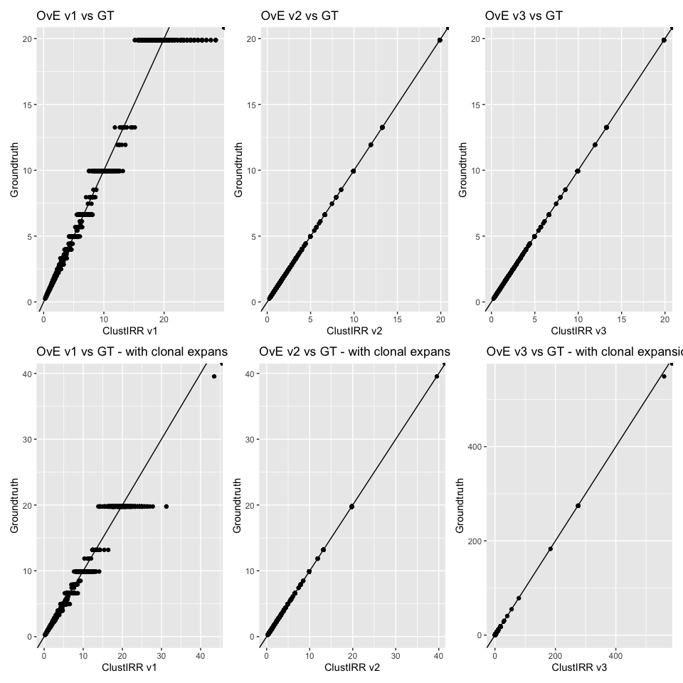

## Check Delta Counts (sanity check for ground truth comparability)

Comparing delta between versions and ground truth versions.

Suffix _e: compared with ground truth expanded  
Suffix _e_u: compared with ground truth expanded and reduced to unique values.

Version 1 has no **n_sample** / **n_ref** output, **OvE** computed with bootstrapping results.

**OvE** different to GT in all versions, but mostly small deviations (see **OvE** section).

For data_sample without clonal expansion in all versions **f_sample**, **n_sample** and **n_ref** no difference to ground truth.

number of rows that are different from ground truth computed with data_sample

| version | ove | f_sample | n_sample | n_ref |
| --- | --- | --- | --- | --- |
| 1 | 3032 | 0 | NA | NA |
| 2 | 3032 | 0 | 0 | 0 |
| 3 | 3032 | 0 | 0 | 0 |

As expected, for data_sample with clonal expansion and ground truth computed without reduction to unique sequences, **f_sample_e** and **n_sample_e** are different between ground truth and version 1/2, but not version 3.

number of rows that are different from ground truth computed with expanded data_sample

| version | ove_e | f_sample_e | n_sample_e | n_ref_e |
| --- | --- | --- | --- | --- |
| 1 | 3042 | 21 | NA | NA |
| 2 | 3042 | 21 | 3099 | 0 |
| 3 | 3042 | 0 | 0 | 0 |

Also as expected, when using the ground truth calculated for data_sample with clonal expansion and reduction to unique sequences, **f_sample** and **n_sample** match between version 1/2 and ground truth, but not version 3.

number of rows that are different from ground truth computed with expanded data_sample, reduced to unique sequences

| version | ove_e_u | f_sample_e_u | n_sample_e_u | n_ref_e_u |
| --- | --- | --- | --- | --- |
| 1 | 3042 | 0 | NA | NA |
| 2 | 3042 | 0 | 0 | 0 |
| 3 | 3042 | 21 | 3099 | 0 |